# Assignment Week 08

Bohan Zhang

2025-04-14

## Prepare the data

#### Download the peakCounts data

```r
options(timeout=6000)
download.file("https://ethz-ins.org/content/mouse_mm38_hippocampus.peakCounts.SE.rds", "atac_peak.rds")
se <- readRDS("atac_peak.rds")
se
```

```
## class: RangedSummarizedExperiment
## dim: 20660 12
## metadata(0):
## assays(1): counts
## rownames: NULL
## rowData names(0):
## colnames(12): Control_female_GSM6041841.bam
##   Control_female_GSM6041842.bam ... FSS_male_GSM6041857.bam
##   FSS_male_GSM6041858.bam
## colData names(1): depth
```

```r
colData(se)$condition <- sub("\\_.*", "",colnames(se))
colData(se)$sex <- sub("^[^_]+_([^_]+)_.*$", "\\1", colnames(se))
row.names(se) <- as.character(granges(se))
head(assay(se, "counts"))
```

```
## 6 x 12 Matrix of class "dgeMatrix"
##                   Control_female_GSM6041841.bam Control_female_GSM6041842.bam
## 1:3012609-3012858                            32                             2
## 1:3094941-3095190                            17                            27
## 1:3113634-3113883                            36                            35
## 1:3119522-3119771                            36                            58
## 1:3119880-3120129                            57                            44
## 1:3120379-3120628                            34                            35
##                   Control_female_GSM6041843.bam Control_male_GSM6041844.bam
## 1:3012609-3012858                             0                          18
## 1:3094941-3095190                             0                           7
## 1:3113634-3113883                            47                          14
## 1:3119522-3119771                           109                           1
## 1:3119880-3120129                             1                           6
## 1:3120379-3120628                             0                          18
##                   Control_male_GSM6041845.bam Control_male_GSM6041846.bam
## 1:3012609-3012858                          30                          27
## 1:3094941-3095190                          13                           9
## 1:3113634-3113883                          55                          19
## 1:3119522-3119771                          10                          16
## 1:3119880-3120129                          14                          18
## 1:3120379-3120628                           4                          30
##                   FSS_female_GSM6041853.bam FSS_female_GSM6041854.bam
## 1:3012609-3012858                        14                        56
## 1:3094941-3095190                         0                        12
## 1:3113634-3113883                        41                        21
## 1:3119522-3119771                        24                        23
## 1:3119880-3120129                        27                        15
## 1:3120379-3120628                         5                        19
##                   FSS_female_GSM6041855.bam FSS_male_GSM6041856.bam
## 1:3012609-3012858                        15                      27
## 1:3094941-3095190                        11                       5
## 1:3113634-3113883                        23                      33
## 1:3119522-3119771                         9                      14
## 1:3119880-3120129                        18                      30
## 1:3120379-3120628                         5                      25
##                   FSS_male_GSM6041857.bam FSS_male_GSM6041858.bam
## 1:3012609-3012858                       9                      14
## 1:3094941-3095190                      12                      17
## 1:3113634-3113883                      17                      53
## 1:3119522-3119771                       5                      34
## 1:3119880-3120129                      23                      41
## 1:3120379-3120628                      13                      36
```

#### Get the genome of Mmu from week 06:

```r
genome <- Rsamtools::FaFile("/mnt/gapp/work/bohan/bioinfo/Week06/genome.fa")
```

#### Get the motifs

```r
motifs <- query(MotifDb, c("HOCOMOCOv10", "Mmusculus"))
# convert to a format motifmatchr can use, and use the gene symbols as names
motifs <- do.call(TFBSTools::PWMatrixList, setNames(
           universalmotif::convert_motifs(motifs, class="TFBSTools-PWMatrix"),
           mcols(motifs)$geneSymbol))
motifs
```

```
## PWMatrixList of length 426
## names(426): AHR AIRE ALX1 ANDR AP2A AP2B ... ZIC1 ZIC2 ZIC3 ZN143 ZN148 ZN423
```

## Perform chromVAR analysis

```r
se <- chromVAR::addGCBias(se, genome=genome)
head(rowData(se))
```

```
## DataFrame with 6 rows and 1 column
##                        bias
##                   <numeric>
## 1:3012609-3012858     0.356
## 1:3094941-3095190     0.428
## 1:3113634-3113883     0.456
## 1:3119522-3119771     0.444
## 1:3119880-3120129     0.428
## 1:3120379-3120628     0.400
```

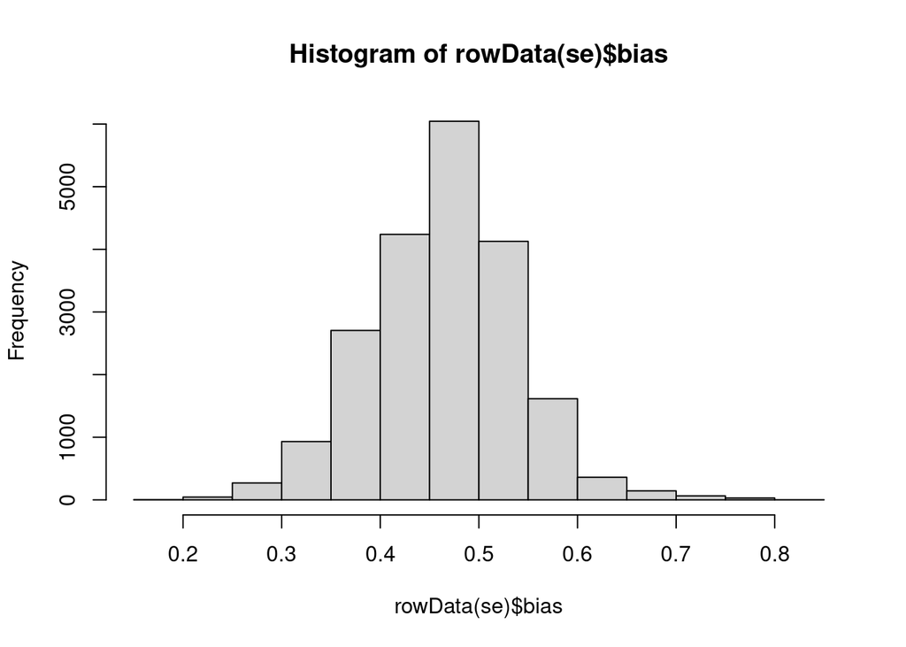

```r
hist(rowData(se)$bias)
```

we can see most of the region have 50%GC, but we also have a little tail at left.

```r
summary(rowData(se)$bias)
```

```
##    Min. 1st Qu.  Median    Mean 3rd Qu.    Max.    NA's
##  0.1680  0.4160  0.4680  0.4657  0.5120  0.8120      80
```

Here we can see in GCbias result there are NAs. This will cause error in next step. so we need to filter it out now.

```r
se <- se[!is.na(rowRanges(se)$bias), ]
summary(rowData(se)$bias)
```

```
##    Min. 1st Qu.  Median    Mean 3rd Qu.    Max.
##  0.1680  0.4160  0.4680  0.4657  0.5120  0.8120
```

```r
moi <- motifmatchr::matchMotifs(motifs, subject=se, genome=genome)
head(assay(moi))
```

```
## 6 x 426 sparse Matrix of class "lgCMatrix"
```

```
##   [[ suppressing 426 column names 'AHR', 'AIRE', 'ALX1' ... ]]
```

[output not shown]

[output cut: 43 more lines]

[output not shown]

```r
set.seed(1234)
# for each peak, we identify similar peaks as background
bg <- chromVAR::getBackgroundPeaks(se, niterations=500)
dev <- chromVAR::computeDeviations(object = se, annotations=moi, background_peaks=bg)
dev
```

```
## class: chromVARDeviations
## dim: 426 12
## metadata(0):
## assays(2): deviations z
## rownames(426): AHR AIRE ... ZN148 ZN423
## rowData names(3): name fractionMatches fractionBackgroundOverlap
## colnames(12): Control_female_GSM6041841.bam
##   Control_female_GSM6041842.bam ... FSS_male_GSM6041857.bam
##   FSS_male_GSM6041858.bam
## colData names(3): depth condition sex
```

## Differential analysis

```r
dev$condition <- factor(dev$condition)
dev$condition <- relevel(dev$condition, "Control")
dev$sex <- factor(dev$sex)
dev$sex <- relevel(dev$sex, "female")
mm <- model.matrix(~condition+sex, data=as.data.frame(colData(dev)))
mm
```

```
##                               (Intercept) conditionFSS sexmale
## Control_female_GSM6041841.bam           1            0       0
## Control_female_GSM6041842.bam           1            0       0
## Control_female_GSM6041843.bam           1            0       0
## Control_male_GSM6041844.bam             1            0       1
## Control_male_GSM6041845.bam             1            0       1
## Control_male_GSM6041846.bam             1            0       1
## FSS_female_GSM6041853.bam               1            1       0
## FSS_female_GSM6041854.bam               1            1       0
## FSS_female_GSM6041855.bam               1            1       0
## FSS_male_GSM6041856.bam                 1            1       1
## FSS_male_GSM6041857.bam                 1            1       1
## FSS_male_GSM6041858.bam                 1            1       1
## attr(,"assign")
## [1] 0 1 2
## attr(,"contrasts")
## attr(,"contrasts")$condition
## [1] "contr.treatment"
##
## attr(,"contrasts")$sex
## [1] "contr.treatment"
```

```r
fit <- limma::eBayes(limma::lmFit(object = assays(dev)$z, design = mm))

res_condition <- as.data.frame(limma::topTable(fit, coef="conditionFSS", number = Inf))
head(res_condition)
```

```
##       ID     logFC    AveExpr         t      P.Value   adj.P.Val          B
## 4   ANDR  6.586212  0.8155048  6.952892 9.535332e-06 0.004062052  3.7740746
## 124  GCR  3.833837  0.5410005  6.079005 3.757056e-05 0.008002529  2.5206731
## 307 PRGR  3.549747  0.2632391  4.661052 4.347595e-04 0.061735851  0.2279098
## 374  TBP -1.213299 -0.1464032 -2.640041 2.026440e-02 0.984341146 -3.3912865
## 2   AIRE  1.484263  0.4920745  2.583538 2.256709e-02 0.984341146 -3.4902929
## 235 NFIA -1.989066  0.2076145 -2.553970 2.387126e-02 0.984341146 -3.5418575
```

```r
res_sex <- as.data.frame(limma::topTable(fit, coef="sexmale", number = Inf))
head(res_sex)
```

```
##        ID     logFC     AveExpr         t      P.Value adj.P.Val          B
## 52   DLX3 -2.379149 -0.08149321 -4.619775 0.0004687503 0.1759880  0.1479869
## 229 NFAC1 -2.126989 -0.26754544 -4.147761 0.0011243191 0.1759880 -0.6238636
## 121 GATA5 -1.762529 -0.28084814 -4.095985 0.0012393519 0.1759880 -0.7102576
## 374   TBP -1.677677 -0.14640324 -3.650490 0.0028928396 0.2475610 -1.4645520
## 185 KLF15 -2.181879 -0.22082037 -3.648188 0.0029056459 0.2475610 -1.4684908
## 243  NFYC -1.958716 -0.40720997 -3.342827 0.0052320537 0.3633513 -1.9931421
```

Comparing stressed and control animals, we can see only the top 3 motifs have the reasonable Padj for significance.

Comparing male and female animals, we choose the top 6 motifs to report.

#### Report for condition

```r
cat("top most significant motifs between conditions: ", res_condition$ID[1:3])
```

```
## top most significant motifs between conditions:  ANDR GCR PRGR
```

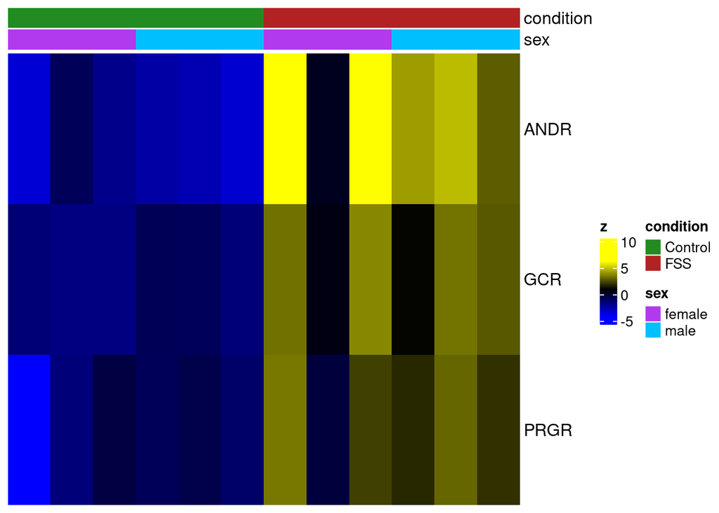

```r
metadata(dev)$anno_colors <- list(condition=c(Control="forestgreen", FSS="firebrick"), sex = c(female="darkorchid2", male="deepskyblue"))
sechm::sechm(dev, features = res_condition$ID[1:3], assayName="z", top_annotation = c("condition", "sex"))
```

In this heatmap we can see: these three motifs all have higher accessibility in condition group than in control group.

ANDR: Androgen Receptor, engaged in neuroplasticity, memory, mood, and responses to stress. Some studies have found that androgens help enhance the brain’s stress resistance. So when under pressure, the androgen and the receptor level may increase.

GCR: Glucocorticoid Receptor, a key component of negative feedback regulation of the HPA axis. The stress response activates the HPA axis, and the rise in cortisol levels inhibits further activation of the hypothalamus and pituitary gland through the GCR. So when under pressure, GCR may have higher accessibility.

PRGR: Progesterone Receptor, engaged in mood regulation, stress resistance and neuroprotection

Also we can see in female FSS group, there is one sample act very differently from others. This may cause some bias or indicate that some animals act very differently from others when going through stress.

#### Report for sex

```r
cat("top most significant motifs between sex: ", head(res_sex$ID))
```

```
## top most significant motifs between sex:  DLX3 NFAC1 GATA5 TBP KLF15 NFYC
```

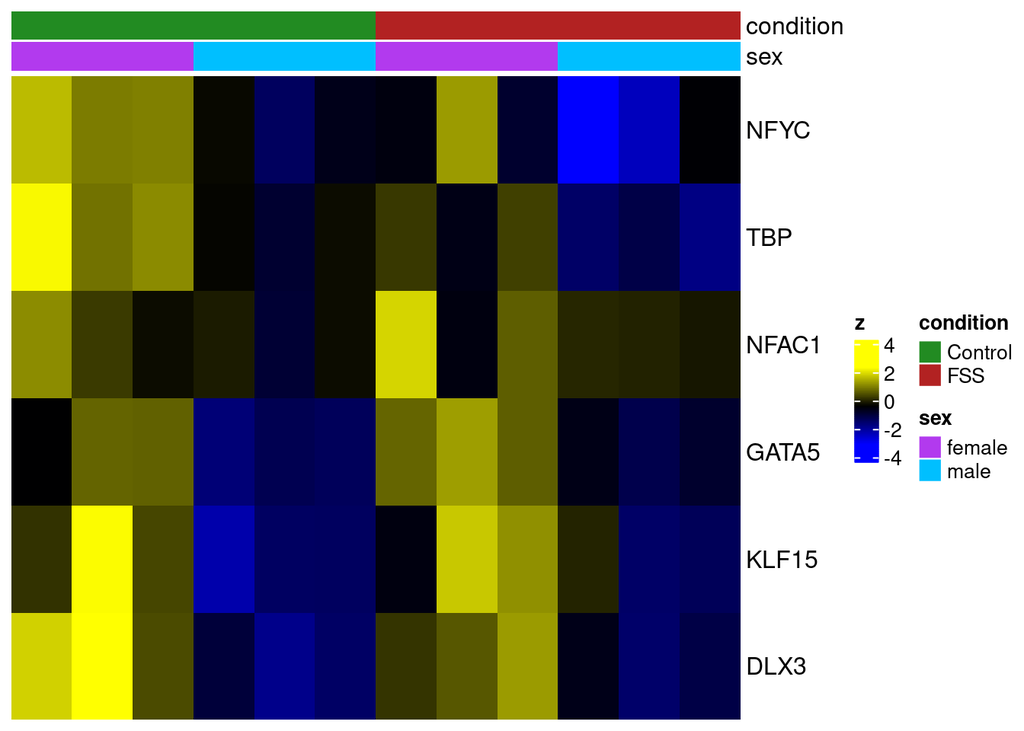

```r
sechm::sechm(dev, features = head(res_sex$ID), assayName="z", top_annotation = c("condition", "sex"))
```

In this heatmap we can see these six motifs have higher accessibility score in female than male samples. Maybe it’s because of the different hormone level between sex.